# Predictive model for flight cancellation - RandomForest method

Here, we aim to build a model to best predict the possibility of flight cancellation based on some of the attributes in the data.

```r
require(randomForest)
require(pROC)
require(caret)
library(e1071)
```

```r
# load the flight delay dataset
df <- read.csv("/Users/naghmehnikpour/Downloads/flight-delays/flights.csv")
summary (df)
```

```
##       YEAR          MONTH             DAY        DAY_OF_WEEK
##  Min.   :2015   Min.   : 1.000   Min.   : 1.0   Min.   :1.000
##  1st Qu.:2015   1st Qu.: 4.000   1st Qu.: 8.0   1st Qu.:2.000
##  Median :2015   Median : 7.000   Median :16.0   Median :4.000
##  Mean   :2015   Mean   : 6.524   Mean   :15.7   Mean   :3.927
##  3rd Qu.:2015   3rd Qu.: 9.000   3rd Qu.:23.0   3rd Qu.:6.000
##  Max.   :2015   Max.   :12.000   Max.   :31.0   Max.   :7.000
##
##     AIRLINE        FLIGHT_NUMBER   TAIL_NUMBER      ORIGIN_AIRPORT
##  WN     :1261855   Min.   :   1          :  14721   ATL    : 346836
##  DL     : 875881   1st Qu.: 730   N480HA :   3768   ORD    : 285884
##  AA     : 725984   Median :1690   N484HA :   3723   DFW    : 239551
##  OO     : 588353   Mean   :2173   N488HA :   3723   DEN    : 196055
##  EV     : 571977   3rd Qu.:3230   N493HA :   3585   LAX    : 194673
##  UA     : 515723   Max.   :9855   N478HA :   3577   SFO    : 148008
##  (Other):1279306                  (Other):5785982   (Other):4408072
##  DESTINATION_AIRPORT SCHEDULED_DEPARTURE DEPARTURE_TIME  DEPARTURE_DELAY
##  ATL    : 346904     Min.   :   1        Min.   :   1    Min.   : -82.00
##  ORD    : 285906     1st Qu.: 917        1st Qu.: 921    1st Qu.:  -5.00
##  DFW    : 239582     Median :1325        Median :1330    Median :  -2.00
##  DEN    : 196010     Mean   :1330        Mean   :1335    Mean   :   9.37
##  LAX    : 194696     3rd Qu.:1730        3rd Qu.:1740    3rd Qu.:   7.00
##  SFO    : 147966     Max.   :2359        Max.   :2400    Max.   :1988.00
##  (Other):4408015                         NA's   :86153   NA's   :86153
##     TAXI_OUT        WHEELS_OFF    SCHEDULED_TIME   ELAPSED_TIME
##  Min.   :  1.00   Min.   :   1    Min.   : 18.0   Min.   : 14
##  1st Qu.: 11.00   1st Qu.: 935    1st Qu.: 85.0   1st Qu.: 82
##  Median : 14.00   Median :1343    Median :123.0   Median :118
##  Mean   : 16.07   Mean   :1357    Mean   :141.7   Mean   :137
##  3rd Qu.: 19.00   3rd Qu.:1754    3rd Qu.:173.0   3rd Qu.:168
##  Max.   :225.00   Max.   :2400    Max.   :718.0   Max.   :766
##  NA's   :89047    NA's   :89047   NA's   :6       NA's   :105071
##     AIR_TIME         DISTANCE        WHEELS_ON        TAXI_IN
##  Min.   :  7.0    Min.   :  21.0   Min.   :   1    Min.   :  1.00
##  1st Qu.: 60.0    1st Qu.: 373.0   1st Qu.:1054    1st Qu.:  4.00
##  Median : 94.0    Median : 647.0   Median :1509    Median :  6.00
##  Mean   :113.5    Mean   : 822.4   Mean   :1471    Mean   :  7.43
##  3rd Qu.:144.0    3rd Qu.:1062.0   3rd Qu.:1911    3rd Qu.:  9.00
##  Max.   :690.0    Max.   :4983.0   Max.   :2400    Max.   :248.00
##  NA's   :105071                    NA's   :92513   NA's   :92513
```

[output cut: 9 more lines]

```
##  Min.   :0.00000    :5729195           Min.   :   0      Min.   :  0
##  1st Qu.:0.00000   A:  25262           1st Qu.:   0      1st Qu.:  0
##  Median :0.00000   B:  48851           Median :   2      Median :  0
##  Mean   :0.01545   C:  15749           Mean   :  13      Mean   :  0
##  3rd Qu.:0.00000   D:     22           3rd Qu.:  18      3rd Qu.:  0
##  Max.   :1.00000                       Max.   :1134      Max.   :573
##                                        NA's   :4755640   NA's   :4755640
##  AIRLINE_DELAY     LATE_AIRCRAFT_DELAY WEATHER_DELAY
##  Min.   :   0      Min.   :   0        Min.   :   0
##  1st Qu.:   0      1st Qu.:   0        1st Qu.:   0
##  Median :   2      Median :   3        Median :   0
##  Mean   :  19      Mean   :  23        Mean   :   3
##  3rd Qu.:  19      3rd Qu.:  29        3rd Qu.:   0
##  Max.   :1971      Max.   :1331        Max.   :1211
##  NA's   :4755640   NA's   :4755640     NA's   :4755640
```

We need to factoralize the cancellation data.

```r
df$CANCELLED <- as.factor( df$CANCELLED )
```

The dataset has nearly 6m lines and both Python and R failed to make a model using the whole data. So we randomly chose 100000 lines from the dataset to build our RandomForest model. From this set, we used 80% of the data for training and 20% for test. To start, we used months, day_of_week and airline as our predictive variables.

```r
dff <- df[ sample( 1:nrow(df), size=100000 ) , ]

select <- sample( 1:nrow(dff), size=nrow(dff)*0.8 )
training <- dff[ select, ]
test <- dff[ -select, ]
fit <- randomForest( CANCELLED ~ MONTH + DAY_OF_WEEK + AIRLINE, data = training )
predicted <- predict( fit, test )
confusionMatrix( predicted, test$CANCELLED )
```

```
## Confusion Matrix and Statistics
##
##           Reference
## Prediction     0     1
##          0 19663   337
##          1     0     0
##
##                Accuracy : 0.9832
##                  95% CI : (0.9813, 0.9849)
##     No Information Rate : 0.9832
##     P-Value [Acc > NIR] : 0.5145
##
##                   Kappa : 0
##  Mcnemar's Test P-Value : <2e-16
##
##             Sensitivity : 1.0000
##             Specificity : 0.0000
##          Pos Pred Value : 0.9831
##          Neg Pred Value :    NaN
##              Prevalence : 0.9831
##          Detection Rate : 0.9831
##    Detection Prevalence : 1.0000
##       Balanced Accuracy : 0.5000
##
##        'Positive' Class : 0
##
```

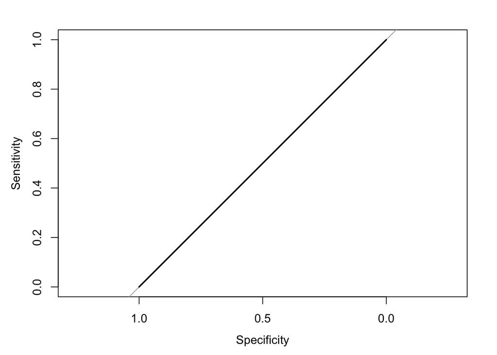

```r
predicted <- predict( fit, test, type = "prob" )
plot( roc(test$CANCELLED,  predicted[,2] ) )
```

## Our approach to handling imbalanced datasets

We will make a new dataset containing all the flights that were cancelled (~90k)+ the same number of flights that were not cancelled(~90k, randomly selected). This new dataset has the same number of cancelled and non-cancelled flights and would be a better choice for making our predictive model.

```r
require(randomForest)
require(pROC)
require(caret)
```

Lets make our new dataset:

```r
dff <- df[ df$CANCELLED == "1" ,  ]
select <- sample( 1:sum( df$CANCELLED == "0" ), size=nrow(dff) )
dff <- rbind( dff, df[ df$CANCELLED == "0" ,  ][ select , ] )

print( sum(dff$CANCELLED=="1") )
```

```
## [1] 89884
```

```r
print( sum(dff$CANCELLED=="0") )
```

```
## [1] 89884
```

Like the last model, we use 80% of the new dataset for training and 20% for test:

```r
select <- sample( 1:nrow(dff), size=nrow(dff)*0.8 )
training <- dff[ select, ]
test <- dff[ -select, ]
nrow(training)
```

```
## [1] 143814
```

```r
nrow(test)
```

```
## [1] 35954
```

## simple model with only three variables

Lets use the same three variables as the last model to create our new model (MONTH + DAY_OF_WEEK + AIRLINE). We also calculate the importance of each of these variants in efficacy of the final model.

```r
fit <- randomForest( CANCELLED ~ MONTH + DAY_OF_WEEK + AIRLINE, data = training )
imp <- importance(fit)
print(imp)
```

```
##             MeanDecreaseGini
## MONTH               5752.386
## DAY_OF_WEEK         1616.913
## AIRLINE             5905.685
```

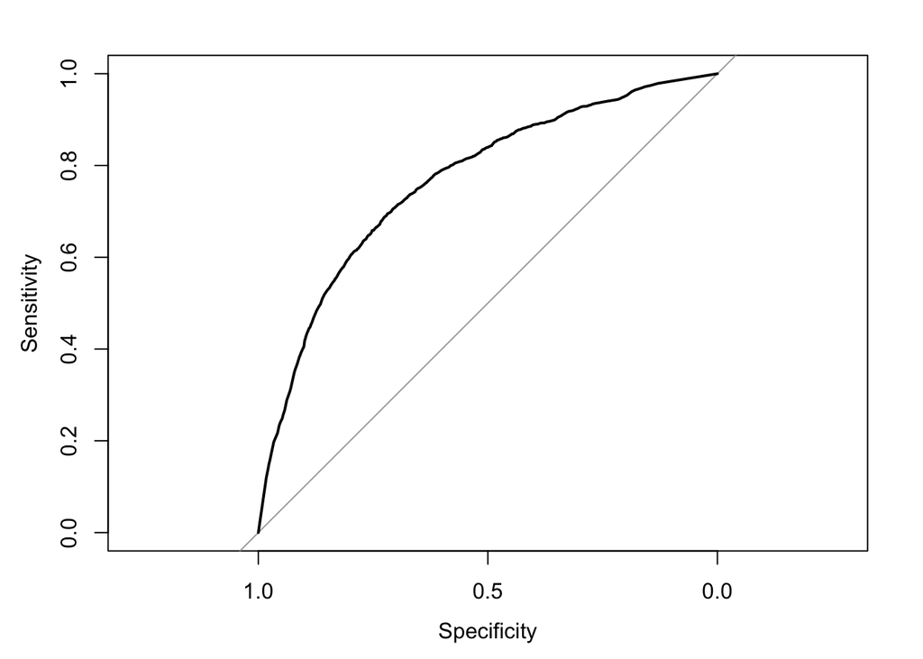

```r
predicted <- predict( fit, test, type = "prob" )
plot( roc( test$CANCELLED, predicted[,2] ) )
```

```r
predicted <- predict( fit, test )
confusionMatrix( predicted, test$CANCELLED )
```

```
## Confusion Matrix and Statistics
##
##           Reference
## Prediction     0     1
##          0 12515  5143
##          1  5454 12842
##
##                Accuracy : 0.7053
##                  95% CI : (0.7005, 0.71)
##     No Information Rate : 0.5002
##     P-Value [Acc > NIR] : <2e-16
##
##                   Kappa : 0.4105
##  Mcnemar's Test P-Value : 0.0026
##
##             Sensitivity : 0.6965
##             Specificity : 0.7140
##          Pos Pred Value : 0.7087
##          Neg Pred Value : 0.7019
##              Prevalence : 0.4998
##          Detection Rate : 0.3481
##    Detection Prevalence : 0.4911
##       Balanced Accuracy : 0.7053
##
##        'Positive' Class : 0
##
```

## Model with more variables

Lets see if adding more variable can change the accuracy of our RandomForest model:

```r
fit <- randomForest( CANCELLED ~ MONTH + DAY_OF_WEEK + AIRLINE + SCHEDULED_DEPARTURE + SCHEDULED_TIME + SCHEDULED_ARRIVAL, data = training[ !is.na( training$SCHEDULED_TIME ),  ] )
imp <- importance(fit)
print(imp)
```

```
##                     MeanDecreaseGini
## MONTH                      10613.135
## DAY_OF_WEEK                 5757.716
## AIRLINE                     9610.414
## SCHEDULED_DEPARTURE        11242.391
## SCHEDULED_TIME             11095.304
## SCHEDULED_ARRIVAL          11694.774
```

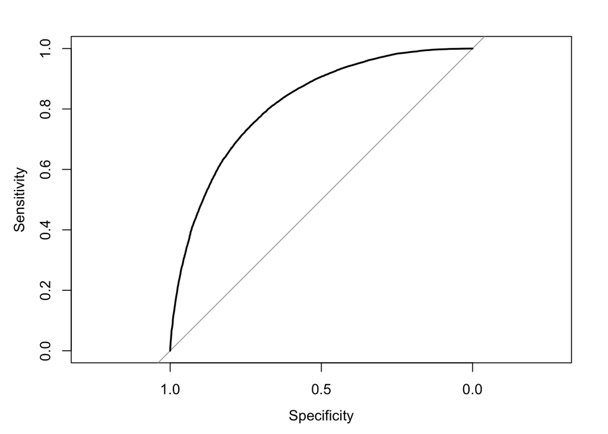

```r
predicted <- predict( fit, test[ !is.na( test$SCHEDULED_TIME ),  ], type = "prob" )
plot( roc( test$CANCELLED[ !is.na( test$SCHEDULED_TIME )  ], predicted[,2] ) )
```

```r
predicted <- predict( fit, test[ !is.na( test$SCHEDULED_TIME ),  ] )
confusionMatrix( predicted, test$CANCELLED[ !is.na( test$SCHEDULED_TIME )  ] )
```

```
## Confusion Matrix and Statistics
##
##           Reference
## Prediction     0     1
##          0 12912  4338
##          1  5057 13645
##
##                Accuracy : 0.7387
##                  95% CI : (0.7341, 0.7432)
##     No Information Rate : 0.5002
##     P-Value [Acc > NIR] : < 2.2e-16
##
##                   Kappa : 0.4774
##  Mcnemar's Test P-Value : 1.286e-13
##
##             Sensitivity : 0.7186
##             Specificity : 0.7588
##          Pos Pred Value : 0.7485
##          Neg Pred Value : 0.7296
##              Prevalence : 0.4998
##          Detection Rate : 0.3591
##    Detection Prevalence : 0.4798
##       Balanced Accuracy : 0.7387
##
##        'Positive' Class : 0
##
```

The accuracy is improved by a few percent. The new added variables have as much importance as the variable “Month”. The reason that the new model performs only slightly better than the last one might be because of the correlations between the new and old variables.

## SVM model: simple model with only three variables

Lets try using Support Vector Machine approach to create our predictive model.

```r
fit <- svm( CANCELLED ~ MONTH + DAY_OF_WEEK + AIRLINE, data = training )

predicted <- predict( fit, data.frame( MONTH = test$MONTH, DAY_OF_WEEK = test$DAY_OF_WEEK, AIRLINE = test$AIRLINE  ) )
confusionMatrix( predicted, test$CANCELLED )
```

```
## Confusion Matrix and Statistics
##
##           Reference
## Prediction     0     1
##          0 12104  6061
##          1  5865 11924
##
##                Accuracy : 0.6683
##                  95% CI : (0.6634, 0.6732)
##     No Information Rate : 0.5002
##     P-Value [Acc > NIR] : < 2e-16
##
##                   Kappa : 0.3366
##  Mcnemar's Test P-Value : 0.07416
##
##             Sensitivity : 0.6736
##             Specificity : 0.6630
##          Pos Pred Value : 0.6663
##          Neg Pred Value : 0.6703
##              Prevalence : 0.4998
##          Detection Rate : 0.3367
##    Detection Prevalence : 0.5052
##       Balanced Accuracy : 0.6683
##
##        'Positive' Class : 0
##
```

Based on the Confusion Matrix statistics, the accuracy of the SVM model is ~ 66% which is lower than Random Foerst model with the same number of variables. So atleast using this dataset, Random Forest model is giving us better predictions.